# Teste ANOVA

# 1, INTRODUÇÃO

1. Nesse estudo, usando o RStudio, vamos analisar um arquivo que armazena a média mensal de vendas de consultores de vendas de uma empresa fictícia
2. O arquivo VEANDAS_MEDIA_MES.csv possui dados de vendas médias mensais de 150 consultores de vendas, que pertencem à três organizações de vendas
3. Os produtos vendidos pelos vendedores nos três departamentos são exatamente os mesmos.
4. O que difere é o segmento de mercado específico para o qual cada departamento é focado
5. Os vendedores com menos de 6 meses( inclusive ), são considerados novatos
6. Os demais, veteranos
7. O objetivo é determinar se existe diferença entre veteranos e novatos, no nível geral de vendas, entre departamentos e também comparar a performance dos três departamentos

# 2. Carregando as livrarias e pacotes

```r
library(ggplot2)
library(ggpubr)
library(tidyverse)
library(broom)
library(AICcmodavg)
library(lemon)
library(knitr)
```

```r
knit_print.data.frame <- lemon_print
```

# 3. Estabelecendo o Ambiente do programa

```r
env<- "C:/data/rstudio_examples/anova"
file <- 'VENDA_MEDIA_MES.csv'
setwd(env)
getwd()
```

```
[1] "C:/data/rstudio_examples/anova"
```

```r
df<- read.csv2(file = file,header=TRUE, sep=';', dec=',' )
#View(df)
```

## 2.1. Criando uma coluna para dizer se o vendedor é veterano ou novato

```r
df['SENIORIDADE'] <- ifelse(df['tempo_funcao']>6,'VETERANO','NOVATO' )

writeLines("td, th { padding : 6px } th { background-color : brown ; color : white; border : 1px solid white; } td { color : brown ; border : 1px solid brown }")
```

```r
kable(df)
```

| vendedor_id | canal_id | tempo_funcao | venda_media_mes | SENIORIDADE |
| --- | --- | --- | --- | --- |
| V1 | canal1 | 2 | 1000 | NOVATO |
| V2 | canal1 | 3 | 2000 | NOVATO |
| V3 | canal1 | 4 | 1000 | NOVATO |
| V4 | canal1 | 5 | 3000 | NOVATO |
| V5 | canal1 | 6 | 7000 | NOVATO |
| V6 | canal1 | 7 | 10000 | VETERANO |
| V7 | canal1 | 8 | 5000 | VETERANO |
| V8 | canal1 | 9 | 6000 | VETERANO |
| V9 | canal1 | 10 | 8000 | VETERANO |
| V10 | canal1 | 2 | 15000 | NOVATO |
| V11 | canal1 | 3 | 2000 | NOVATO |
| V12 | canal1 | 4 | 3000 | NOVATO |
| V13 | canal1 | 5 | 4000 | NOVATO |
| V14 | canal1 | 6 | 9000 | NOVATO |
| V15 | canal1 | 7 | 7000 | VETERANO |
| V16 | canal1 | 8 | 3000 | VETERANO |
| V17 | canal1 | 9 | 5000 | VETERANO |
| V18 | canal1 | 10 | 8000 | VETERANO |
| V19 | canal1 | 2 | 9000 | NOVATO |
| V20 | canal1 | 3 | 1000 | NOVATO |
| V21 | canal1 | 4 | 3000 | NOVATO |
| V22 | canal1 | 5 | 5000 | NOVATO |
| V23 | canal1 | 6 | 4000 | NOVATO |
| V24 | canal1 | 7 | 6000 | VETERANO |
| V25 | canal1 | 8 | 3000 | VETERANO |
| V26 | canal1 | 9 | 1000 | VETERANO |
| V27 | canal1 | 10 | 1000 | VETERANO |
| V28 | canal1 | 2 | 5000 | NOVATO |
| V29 | canal1 | 3 | 6000 | NOVATO |
| V30 | canal1 | 4 | 7000 | NOVATO |

[output cut: 120 more lines]

# 3. Análise preliminr dos dados

```r
summary(df)
```

```
 vendedor_id          canal_id          tempo_funcao   venda_media_mes
 Length:150         Length:150         Min.   : 2.00   Min.   : 1000
 Class :character   Class :character   1st Qu.: 4.00   1st Qu.: 3000
 Mode  :character   Mode  :character   Median : 6.00   Median : 5000
                                       Mean   : 5.94   Mean   : 4993
                                       3rd Qu.: 8.00   3rd Qu.: 7000
                                       Max.   :10.00   Max.   :15000
 SENIORIDADE.tempo_funcao
 Length:150
 Class :character
 Mode  :character
```

## 3.1. Transformando variávies em fatores

```r
df$canal_id <- as.factor( df$canal_id)

df$SENIORIDADE <- as.factor(df$SENIORIDADE)
```

# 4. Análise ANOVA dos Grupos de Vendas: canal1, canal2, canal3

Para esse teste, vamos usar o ONE-WAY-ANOVA.

## 4.1. Desenhando o gráfico de Box Plot

Antes de iniciar a análise ANOVA, propriamente dita, vamos imprimir um gáfidco de box-plot onde a varíavel categórica é canal_id.

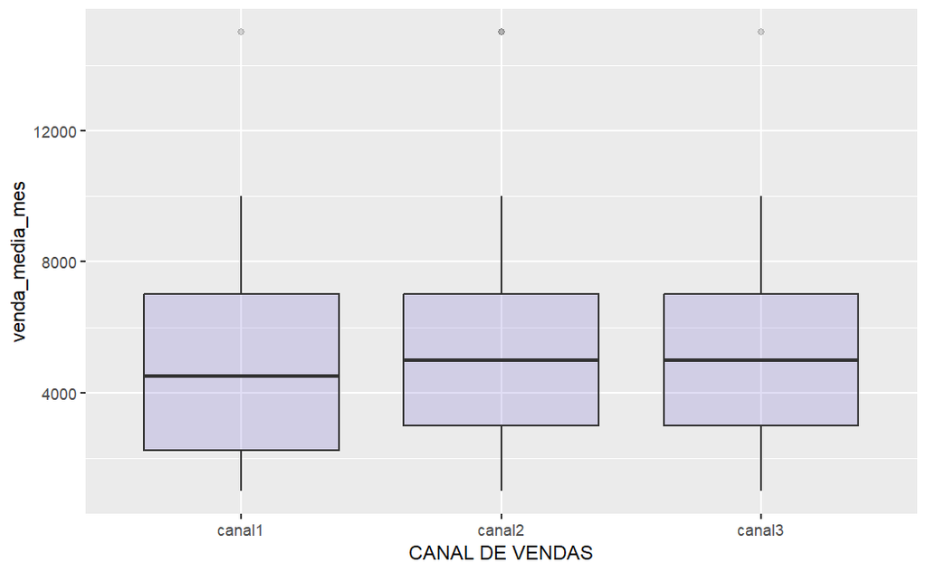

```r
ggplot(data=df,aes(x=as.factor(canal_id) , y=venda_media_mes ))+ geom_boxplot(fill='slateblue', alpha=0.2)+ xlab('CANAL DE VENDAS')
```

O gráfico, aparentemente, mostra que não há muita diferença na média de vendas entre canais; além disso, parece haver uma variação maior nas vendas do canal 1.

# 4.2. ONE WAY ANOVA

```r
one.way <- aov(  venda_media_mes ~ canal_id, data=df  )
summary(one.way)
```

```
             Df    Sum Sq  Mean Sq F value Pr(>F)
canal_id      2 9.213e+06  4606667   0.456  0.634
Residuals   147 1.484e+09 10093741
```

O valor de $Pr(>F_{critico})$ indica que não há diferença significativa entre a média de vendas mensais dos três canais, confirmando aquilo que já havíamos visto nos gráficos.

Vamos analisar agora se existe diferença em função da senioridade

## 4.3. Senioridade

Antes, vamos novamente imprimir um novo gráfico de box plot, onde a variável categórica é a senioridade

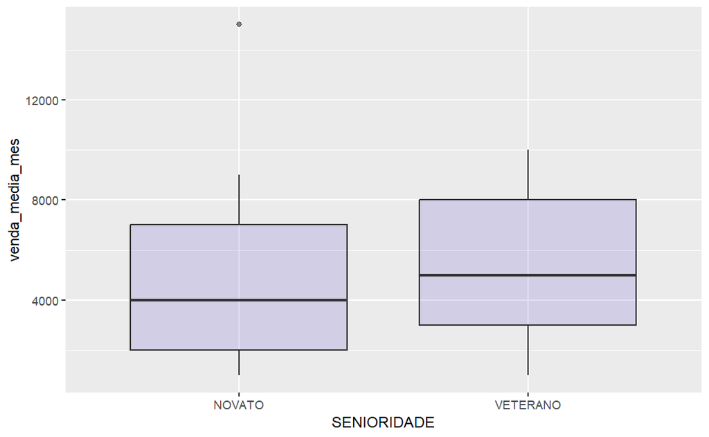

```r
ggplot(data=df,aes(x=as.factor(SENIORIDADE) , y=venda_media_mes ))+ geom_boxplot(fill='slateblue', alpha=0.2)+ xlab('SENIORIDADE')
```

Aqui, o gráfico parece indicar que existe uma diferença de desempenho entre veteranos( com uma média ligeiramente superior) e novatos.

Vamos fazer a análise anova ONEWAY

```r
one.way2 <- aov(  venda_media_mes ~SENIORIDADE, data=df  )
summary(one.way2)
```

```
             Df    Sum Sq  Mean Sq F value Pr(>F)
SENIORIDADE   1 1.491e+07 14908265   1.493  0.224
Residuals   148 1.478e+09  9987061
```

O valor de p-value é de 0.224, muito acima dos 0.05 para o nível de significância de rejeição da hipótese nula. Portanto, concluímos que as médias de vendas não parecem mudar muito quando se compara veteranos e novatos.

Vamos agora, analisar os dois fatores - CANAL e Senioridade - em conjunto

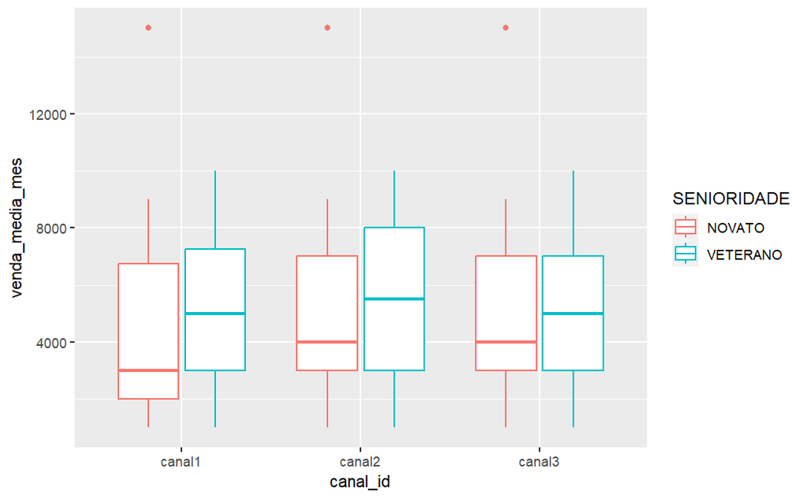

```r
ggplot(df, aes(x = canal_id, y =venda_media_mes , color = SENIORIDADE)) +  geom_boxplot()
```

Vamos realizar a análise anova two way

```r
two.way <- aov( venda_media_mes ~ canal_id + SENIORIDADE, data=df)
summary(two.way)
```

```
             Df    Sum Sq  Mean Sq F value Pr(>F)
canal_id      2 9.213e+06  4606667   0.457  0.634
SENIORIDADE   1 1.342e+07 13419324   1.332  0.250
Residuals   146 1.470e+09 10070964
```

# 5. Comparando desempenho de veteranos e novatos no canal 1

```r
df_canal1 <- df %>% filter(canal_id =='canal1')
```

```r
head(df_canal1)
```

|  | vendedor_id | canal_id | tempo_funcao | venda_media_mes | SENIORIDADE |
| --- | --- | --- | --- | --- | --- |
| 1 | V1 | canal1 | 2 | 1000 | NOVATO |
| 2 | V2 | canal1 | 3 | 2000 | NOVATO |
| 3 | V3 | canal1 | 4 | 1000 | NOVATO |
| 4 | V4 | canal1 | 5 | 3000 | NOVATO |
| 5 | V5 | canal1 | 6 | 7000 | NOVATO |
| 6 | V6 | canal1 | 7 | 10000 | VETERANO |

```r
one.way3 <- aov(  venda_media_mes ~SENIORIDADE, data=df_canal1  )
summary(one.way3)
```

```
            Df    Sum Sq Mean Sq F value Pr(>F)
SENIORIDADE  1   7680000 7680000   0.797  0.376
Residuals   48 462400000 9633333
```

```r
df_canal2 <- df %>% filter(canal_id =='canal2')
one.way4 <- aov(  venda_media_mes ~SENIORIDADE, data=df_canal2  )
summary(one.way4)
```

```
            Df    Sum Sq  Mean Sq F value Pr(>F)
SENIORIDADE  1   2267821  2267821   0.197  0.659
Residuals   48 552612179 11512754
```

```r
df_canal3 <- df %>% filter(canal_id =='canal3')
one.way5 <- aov(  venda_media_mes ~SENIORIDADE, data=df_canal3  )
summary(one.way5)
```

```
            Df    Sum Sq Mean Sq F value Pr(>F)
SENIORIDADE  1   4327389 4327389   0.457  0.502
Residuals   48 454492611 9468596
```

Quando os canais são isolados, a análise ANOVA ONE.WAY indica que não há diferença significativa entre veteranos e novatos.